# Problem Set 3 Solutions

# Question 1

Consider the $ARMA(1,1)$ process
$$\begin{align}
Y_t & = 3.2 + 0.86 Y_{t-1} + \varepsilon_t - 1.4 \varepsilon_{t-1}, \,\, \varepsilon_t \sim WN(0,1).
\end{align}$$

Simulate $n=1010$ observations of this process.

#### Solution:

```r
n = 1e4
steps = 10
cc = 3.2
phi = 0.86
theta = -1.4
eps = rnorm(n+steps,0,1)
y = rep(NA,n+steps)
y[1] = cc + phi*cc/(1-phi)
for(i in 2:(n+steps)){
  y[i] = cc + phi*y[i-1] + eps[i] + theta*eps[i-1]
}
```

### a. (10 points)

Use the first 1000 observations from your simulation to estimate an $ARMA(1,1)$ model. Feel free to use the `arima` function. Report your parameter estimates with standard errors and the variance of the residuals. Use your the parameter estimates to compute and report forecasts for $s=1,\ldots,10$. Do not use any pre-packaged functions in `R` – compute and report the forecasts using basic mathematical operations.

#### Solution:

The parameter estimates are very close to the invertible representation of the $ARMA(1,1)$:

```r
arma11Est = arima(y[1:n],order=c(1,0,1))
arma11Est$coef
```

```
       ar1        ma1  intercept
 0.8554169 -0.7078553 22.8333523
```

```r
sqrt(diag(arma11Est$var.coef))
```

```
       ar1        ma1  intercept
0.01409413 0.01929140 0.02848634
```

Specifically, the true parameters of the invertible representation are within two standard deviations of the parameter estimates. Further, the variance of the residuals is very close to the variance of the white noise process in the invertible representation:

```r
var(arma11Est$residuals)
```

```
[1] 1.98911
```

From the lecture notes, given final period $t$, we know that $\hat{Y}_{t+1|t} = \mu + \phi(Y_t-\mu) + \theta \varepsilon_t$. Subsequent forecasts are then $\hat{Y}_{t+s|t} = \mu + \phi(\hat{Y}_{t+s-1|t}-\mu)$ for $s\geq 2$:

```r
muHat = arma11Est$coef[3]
phiHat = arma11Est$coef[1]
thetaHat = arma11Est$coef[2]
yHat = rep(NA,steps)
yHat[1] =  muHat + phiHat*(y[n]-muHat) + thetaHat*eps[n]
for(s in 2:steps){
  yHat[s] = muHat + phiHat*(yHat[s-1]-muHat)
}
yHat
```

```
 [1] 23.98774 23.82084 23.67806 23.55593 23.45146 23.36209 23.28565 23.22025 23.16431 23.11646
```

### b. (10 points)

Estimate an $AR(1)$ model using the first 1000 observations from your simulation. Do not use the `arima` function or any other pre-packaged function. Instead, compute the esimates with matrix operations. Use the parameter estimates to compute and report forecasts for $s=1,\ldots,10$. Do not use any pre-packaged functions in `R` – compute and report the forecasts using basic mathematical operations.

#### Solution:

The parameter estimates are obtained via linear regression:

```r
nObs = n-1
Y = y[2:n]
X = cbind(rep(1,nObs),y[1:(n-1)])
beta = solve(t(X)%*%X)%*%t(X)%*%Y
beta
```

```
           [,1]
[1,] 18.1512010
[2,]  0.2050592
```

The standard errors are:

```r
sigma2Hat = as.numeric(var(Y - X%*%beta))
seBeta = sqrt(diag(sigma2Hat*solve(t(X)%*%X)))
seBeta
```

```
[1] 0.22397522 0.00978902
```

```r
steps = 10
phiHat = beta[2]
muHat = beta[1]/(1-phiHat)
yHat = rep(NA,steps)
yHat[1] =  muHat + phiHat*(y[n]-muHat)
for(s in 2:steps){
  yHat[s] = muHat + muHat + phiHat*(yHat[s-1]-muHat)
}
yHat
```

```
 [1] 23.14401 45.73049 50.36205 51.31180 51.50655 51.54649 51.55468 51.55636 51.55670 51.55677
```

These forecasts are much poorer than those of the estimated $ARMA(1,1)$.

### c. (15 points)

Compute the theoretical MSE values for the forecasts associated with $s=1,\ldots,10$, using both the $ARMA(1,1)$ and $AR(1)$ parameter estimates.

#### Solution:

In lecture, we derived the $MA$ coefficients associated with an $ARMA(1,1)$ process:
$$\begin{align}
\psi_j & = \phi^j + \phi^{j-1} \theta, \,\,\, j \geq 1.
\end{align}$$
Using the general expression for forecast MSEs, we arrive at the following formula for the theoretical MSE values of the $ARMA(1,1)$:
$$\begin{align}
MSE_s & = \sigma^2 \sum_{j=0}^{s-1} \psi_j^2 \\
& = \sigma^2 \left(1 + {\bf I}_{s>0} \sum_{j=1}^{s-1} \left(\phi^j + \phi^{j-1} \theta \right)^2\right).
\end{align}$$

where ${\bf I}_{s>0}$ is the indicator function for the event that $s>0$. Using the estimated values from part (a), the theoretical MSEs are:

```r
muHat = arma11Est$coef[3]
phiHat = arma11Est$coef[1]
thetaHat = arma11Est$coef[2]
sigma2Hat = var(arma11Est$residuals)
sigma2Hat*cumsum(c(1,phiHat^(1:9) + phiHat^(0:8)*thetaHat)^2)
```

```
 [1] 1.989110 2.032421 2.064114 2.087305 2.104275 2.116692 2.125778 2.132427 2.137292 2.140852
```

Similarly, the formula for the theoretical MSE values of the $AR(1)$ is:
$$\begin{align}
MSE_s & = \sigma^2 \sum_{j=0}^{s-1} \psi_j^2 \\
& = \sigma^2 \sum_{j=0}^{s-1} \left(\phi^j\right)^2.
\end{align}$$

Using the estimated values from part (b), the theoretical MSEs are:

```r
phiHat = beta[2]
sigma2Hat = sigma2Hat = as.numeric(var(Y - X%*%beta))
cumsum(sigma2Hat*phiHat^(0:9))
```

```
 [1] 2.060350 2.482844 2.569480 2.587245 2.590888 2.591635 2.591789 2.591820 2.591826 2.591828
```

### d. (25 points)

Simulate 100 new datasets of size $n=1010$. For each dataset, estimate the $ARMA(1,1)$ and $AR(1)$ models using the first $1000$ observations and compute the forecasts for $s=1,\ldots,10$. Compute the forecast errors for each set of forecasts (using the true values that you simulated), and compute the sample MSEs of your forecasts.

#### Solution:

```r
nMC = 100
steps = 10
n = 1e4
cc = 3.2
phi = 0.86
theta = -1.4
Y = matrix(NA,nrow=(n+steps),ncol=nMC)
YHatARMA = matrix(NA,nrow=steps,ncol=nMC)
YHatAR = matrix(NA,nrow=steps,ncol=nMC)
Eps = matrix(rnorm((n+steps)*nMC,0,1),nrow=(n+steps))
Y[1,] = cc + phi*cc/(1-phi)
for(j in 1:nMC){
  for(i in 2:(n+steps)){
    Y[i,j] = cc + phi*Y[i-1,j] + Eps[i,j] + theta*Eps[i-1,j]
  }
  # ARMA(1,1) forecasts
  arma11Est = arima(y[1:n],order=c(1,0,1))
  muHat = arma11Est$coef[3]
  phiHat = arma11Est$coef[1]
  thetaHat = arma11Est$coef[2]
  YHatARMA[1,j] =  muHat + phiHat*(Y[n,j]-muHat) + thetaHat*Eps[n,j]
  for(s in 2:steps){
    YHatARMA[s,j] = muHat + phiHat*(YHatARMA[s-1,j]-muHat)
  }
  # AR(1) forecasts
  ar1Est = arima(y[1:n],order=c(1,0,0))
  muHat = ar1Est$coef[2]
  phiHat = ar1Est$coef[1]
  YHatAR[1,j] =  muHat + phiHat*(Y[n,j]-muHat)
  for(s in 2:steps){
    YHatAR[s,j] = muHat + phiHat*(YHatAR[s-1,j]-muHat)
  }
}
apply((YHatARMA - Y[(n+1):(n+steps),])^2,1,mean)
```

```
 [1] 1.697611 1.838785 1.644116 1.970509 2.224998 1.741789 2.115074 2.109444 2.049940 1.794033
```

```r
apply((YHatAR - Y[(n+1):(n+steps),])^2,1,mean)
```

```
 [1] 2.088617 2.006939 1.891889 2.032346 2.320653 1.809094 2.018107 2.120156 2.002447 1.836266
```

# Question 2

Download daily 1-year and 10-year U.S. Treasury yield data for the period May 21, 2013 - May 20, 2018.

### part a. (10 points)

Estimate a bivariate $VAR$ for the log interest rates. Report your parameter estimates and provide some interpretation.

#### Solution:

After importing the data via Quandl and computing log interest rates, the `VARselect` function can be used to compare the fit of various VAR models and to select an order:

```r
library(Quandl)
library(vars)
rates = Quandl("USTREASURY/YIELD",start_date='2013-05-21',end_date='2018-05-20',type='xts')
rate1 = log(rates[,'1 YR'])
rate10 = log(rates[,'10 YR'])
rateData = cbind(rate1,rate10)
VARselect(rateData)
```

```
$selection
AIC(n)  HQ(n)  SC(n) FPE(n)
     2      2      2      2

$criteria
                   1             2             3             4             5             6             7             8             9
AIC(n) -1.379016e+01 -1.381650e+01 -1.381196e+01 -1.381185e+01 -1.380662e+01 -1.380500e+01 -1.380083e+01 -1.380767e+01 -1.380599e+01
HQ(n)  -1.378084e+01 -1.380097e+01 -1.379023e+01 -1.378391e+01 -1.377246e+01 -1.376463e+01 -1.375425e+01 -1.375488e+01 -1.374699e+01
SC(n)  -1.376539e+01 -1.377521e+01 -1.375416e+01 -1.373754e+01 -1.371579e+01 -1.369766e+01 -1.367697e+01 -1.366730e+01 -1.364910e+01
FPE(n)  1.025674e-06  9.990113e-07  1.003553e-06  1.003664e-06  1.008928e-06  1.010566e-06  1.014791e-06  1.007873e-06  1.009572e-06
                  10
AIC(n) -1.380282e+01
HQ(n)  -1.373761e+01
SC(n)  -1.362941e+01
FPE(n)  1.012781e-06
```

All four information criteria are minimized at $p=2$, so we can use this order to estimate a VAR model:

```r
varEst = VAR(rateData,p=2)
summary(varEst)
```

```
VAR Estimation Results:
=========================
Endogenous variables: X1.YR, X10.YR
Deterministic variables: const
Sample size: 1249
Log Likelihood: 5092.513
Roots of the characteristic polynomial:
0.9992 0.9944 0.1802 0.04099
Call:
VAR(y = rateData, p = 2)


Estimation results for equation X1.YR:
======================================
X1.YR = X1.YR.l1 + X10.YR.l1 + X1.YR.l2 + X10.YR.l2 + const

           Estimate Std. Error t value Pr(>|t|)
X1.YR.l1   0.826220   0.030147  27.406  < 2e-16 ***
X10.YR.l1  0.176493   0.080060   2.205   0.0277 *
X1.YR.l2   0.172899   0.030155   5.734 1.23e-08 ***
X10.YR.l2 -0.188772   0.080197  -2.354   0.0187 *
const      0.012069   0.007616   1.585   0.1133
---
Signif. codes:  0 ‘***’ 0.001 ‘**’ 0.01 ‘*’ 0.05 ‘.’ 0.1 ‘ ’ 1


Residual standard error: 0.05326 on 1244 degrees of freedom
Multiple R-Squared: 0.9972, Adjusted R-squared: 0.9972
F-statistic: 1.098e+05 on 4 and 1244 DF,  p-value: < 2.2e-16


Estimation results for equation X10.YR:
=======================================
X10.YR = X1.YR.l1 + X10.YR.l1 + X1.YR.l2 + X10.YR.l2 + const

           Estimate Std. Error t value Pr(>|t|)
X1.YR.l1   0.005105   0.011484   0.445   0.6567
X10.YR.l1  0.946101   0.030498  31.022   <2e-16 ***
X1.YR.l2  -0.005055   0.011487  -0.440   0.6600
X10.YR.l2  0.047978   0.030550   1.570   0.1166
const      0.005258   0.002901   1.813   0.0701 .
---
Signif. codes:  0 ‘***’ 0.001 ‘**’ 0.01 ‘*’ 0.05 ‘.’ 0.1 ‘ ’ 1


Residual standard error: 0.02029 on 1244 degrees of freedom
Multiple R-Squared: 0.9853, Adjusted R-squared: 0.9852
F-statistic: 2.084e+04 on 4 and 1244 DF,  p-value: < 2.2e-16



Covariance matrix of residuals:
           X1.YR    X10.YR
X1.YR  0.0028365 0.0004175
X10.YR 0.0004175 0.0004116

Correlation matrix of residuals:
        X1.YR X10.YR
X1.YR  1.0000 0.3864
X10.YR 0.3864 1.0000
```

Interestingly, not all the parameter estimates in the fitted model are significant: the constant term in the 1-year rate equation has a $p$-value of 0.1133 and only the first lag of the 10-year rate is significant at a 5% level in the 10-year equation. This suggests that fitting a constrained version (with various parameters set to zero) of the second-order VAR might be preferable.

### b. (15 points)

Compute and report the impulse response functions of the fitted $VAR$ model.

#### Solution:

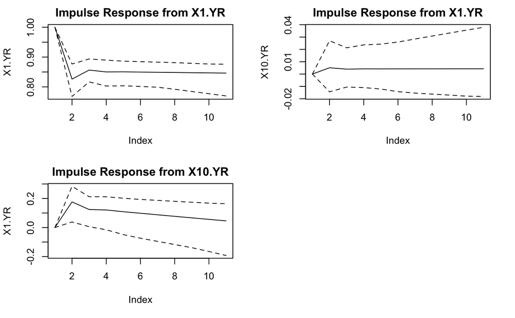

### c. (10 points)

Use the fitted $VAR$ model to compute and report 15-step forecasts for the two series.

#### Solution

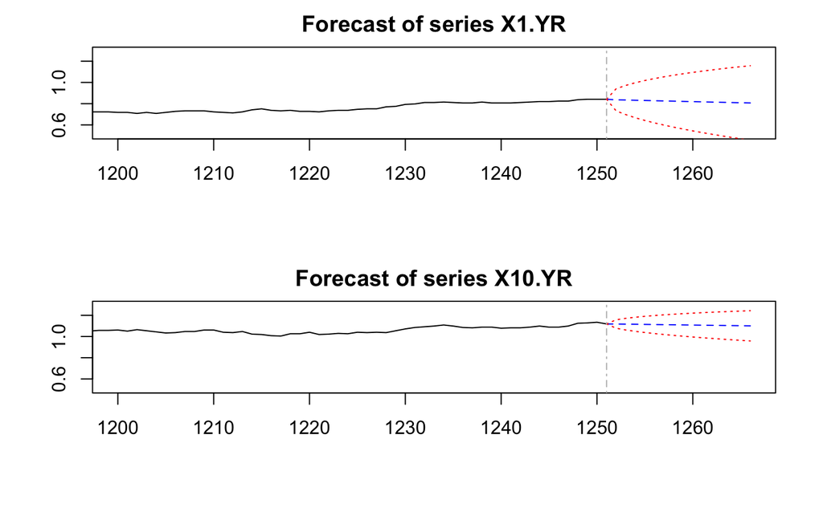